# Loan Data exploration

## by Mohammad Hosameldin Taha Mohamed Saleh

## Preliminary Wrangling

This document explores a dataset containing contains 113,937 loans with 81 variables on each loan, including loan amount, borrower rate (or interest rate), current loan status, borrower income, and many others.

```python
# import all packages and set plots to be embedded inline
import numpy as np
import pandas as pd
import matplotlib.pyplot as plt
import seaborn as sb

%matplotlib inline
```

> Load in your dataset and describe its properties through the questions below. Try and motivate your exploration goals through this section.

What factors affect a loan’s outcome status?

What affects the borrower’s APR or interest rate?

Are there differences between loans depending on how large the original loan amount was?

```python
df = pd.read_csv('prosperLoanData.csv')
```

```python
# high-level overview of data shape and composition
print(df.shape)
print(df.dtypes)
df.head(2)
```

```
(113937, 81)
ListingKey                      object
ListingNumber                    int64
ListingCreationDate             object
CreditGrade                     object
Term                             int64
                                ...
PercentFunded                  float64
Recommendations                  int64
InvestmentFromFriendsCount       int64
InvestmentFromFriendsAmount    float64
Investors                        int64
Length: 81, dtype: object
```

|  | ListingKey | ListingNumber | ListingCreationDate | CreditGrade | Term | LoanStatus | ClosedDate | BorrowerAPR | BorrowerRate | LenderYield | ... | LP_ServiceFees | LP_CollectionFees | LP_GrossPrincipalLoss | LP_NetPrincipalLoss | LP_NonPrincipalRecoverypayments | PercentFunded | Recommendations | InvestmentFromFriendsCount | InvestmentFromFriendsAmount | Investors |
| --- | --- | --- | --- | --- | --- | --- | --- | --- | --- | --- | --- | --- | --- | --- | --- | --- | --- | --- | --- | --- | --- |
| 0 | 1021339766868145413AB3B | 193129 | 2007-08-26 19:09:29.263000000 | C | 36 | Completed | 2009-08-14 00:00:00 | 0.16516 | 0.158 | 0.138 | ... | -133.18 | 0.0 | 0.0 | 0.0 | 0.0 | 1.0 | 0 | 0 | 0.0 | 258 |
| 1 | 10273602499503308B223C1 | 1209647 | 2014-02-27 08:28:07.900000000 | NaN | 36 | Current | NaN | 0.12016 | 0.092 | 0.082 | ... | 0.00 | 0.0 | 0.0 | 0.0 | 0.0 | 1.0 | 0 | 0 | 0.0 | 1 |

2 rows × 81 columns

```python
g = df.columns.to_series().groupby(df.dtypes).groups
{k.name: v for k, v in g.items()}
```

```
{'bool': Index(['IsBorrowerHomeowner', 'CurrentlyInGroup', 'IncomeVerifiable'], dtype='object'),
 'int64': Index(['ListingNumber', 'Term', 'ListingCategory (numeric)',
        'OpenRevolvingAccounts', 'LoanCurrentDaysDelinquent',
        'LoanMonthsSinceOrigination', 'LoanNumber', 'LoanOriginalAmount',
        'Recommendations', 'InvestmentFromFriendsCount', 'Investors'],
       dtype='object'),
 'float64': Index(['BorrowerAPR', 'BorrowerRate', 'LenderYield', 'EstimatedEffectiveYield',
        'EstimatedLoss', 'EstimatedReturn', 'ProsperRating (numeric)',
        'ProsperScore', 'EmploymentStatusDuration', 'CreditScoreRangeLower',
        'CreditScoreRangeUpper', 'CurrentCreditLines', 'OpenCreditLines',
        'TotalCreditLinespast7years', 'OpenRevolvingMonthlyPayment',
        'InquiriesLast6Months', 'TotalInquiries', 'CurrentDelinquencies',
        'AmountDelinquent', 'DelinquenciesLast7Years',
        'PublicRecordsLast10Years', 'PublicRecordsLast12Months',
        'RevolvingCreditBalance', 'BankcardUtilization',
        'AvailableBankcardCredit', 'TotalTrades',
        'TradesNeverDelinquent (percentage)', 'TradesOpenedLast6Months',
        'DebtToIncomeRatio', 'StatedMonthlyIncome', 'TotalProsperLoans',
        'TotalProsperPaymentsBilled', 'OnTimeProsperPayments',
        'ProsperPaymentsLessThanOneMonthLate',
        'ProsperPaymentsOneMonthPlusLate', 'ProsperPrincipalBorrowed',
        'ProsperPrincipalOutstanding', 'ScorexChangeAtTimeOfListing',
        'LoanFirstDefaultedCycleNumber', 'MonthlyLoanPayment',
        'LP_CustomerPayments', 'LP_CustomerPrincipalPayments',
        'LP_InterestandFees', 'LP_ServiceFees', 'LP_CollectionFees',
        'LP_GrossPrincipalLoss', 'LP_NetPrincipalLoss',
        'LP_NonPrincipalRecoverypayments', 'PercentFunded',
        'InvestmentFromFriendsAmount'],
       dtype='object'),
 'object': Index(['ListingKey', 'ListingCreationDate', 'CreditGrade', 'LoanStatus',
        'ClosedDate', 'ProsperRating (Alpha)', 'BorrowerState', 'Occupation',
        'EmploymentStatus', 'GroupKey', 'DateCreditPulled',
        'FirstRecordedCreditLine', 'IncomeRange', 'LoanKey',
        'LoanOriginationDate', 'LoanOriginationQuarter', 'MemberKey'],
       dtype='object')}
```

```python
print(df['CreditGrade'].unique())
print(df['LoanStatus'].unique())
print(df['ProsperRating (Alpha)'].unique())
print(df['EmploymentStatus'].unique())
print(df['IncomeRange'].unique())
print(sorted(df['LoanOriginationQuarter'].unique(), key=lambda x: x.split()[1]))
```

```
['C' nan 'HR' 'AA' 'D' 'B' 'E' 'A' 'NC']
['Completed' 'Current' 'Past Due (1-15 days)' 'Defaulted' 'Chargedoff'
 'Past Due (16-30 days)' 'Cancelled' 'Past Due (61-90 days)'
 'Past Due (31-60 days)' 'Past Due (91-120 days)' 'FinalPaymentInProgress'
 'Past Due (>120 days)']
[nan 'A' 'D' 'B' 'E' 'C' 'AA' 'HR']
['Self-employed' 'Employed' 'Not available' 'Full-time' 'Other' nan
 'Not employed' 'Part-time' 'Retired']
['$25,000-49,999' '$50,000-74,999' 'Not displayed' '$100,000+'
 '$75,000-99,999' '$1-24,999' 'Not employed' '$0']
['Q4 2005', 'Q3 2006', 'Q4 2006', 'Q2 2006', 'Q1 2006', 'Q3 2007', 'Q1 2007', 'Q4 2007', 'Q2 2007', 'Q3 2008', 'Q1 2008', 'Q2 2008', 'Q4 2008', 'Q3 2009', 'Q4 2009', 'Q2 2009', 'Q2 2010', 'Q4 2010', 'Q1 2010', 'Q3 2010', 'Q4 2011', 'Q2 2011', 'Q1 2011', 'Q3 2011', 'Q4 2012', 'Q2 2012', 'Q1 2012', 'Q…
```

```python
# convert CreditGrade, color, and clarity into ordered categorical types
ordinal_var_dict = {'CreditGrade': ['NC', 'HR', 'E', 'D', 'C', 'B', 'A', 'AA'],
                    'LoanStatus': ['Chargedoff', 'Cancelled',  'Current', 'Defaulted', 'Past Due (1-15 days)',
 'Past Due (16-30 days)' , 'Past Due (31-60 days)', 'Past Due (61-90 days)',
  'Past Due (91-120 days)', 'Past Due (>120 days)','FinalPaymentInProgress', 'Completed'],
                    'ProsperRating (Alpha)': [ 'HR', 'E', 'D', 'C', 'B', 'A', 'AA'],
                    'EmploymentStatus': [ 'Not available', 'Other', 'Not employed','Retired',  'Part-time', 'Employed', 'Full-time'],
                    'IncomeRange': ['Not displayed', '$0','Not employed', '$1-24,999','$25,000-49,999',  '$50,000-74,999', '$75,000-99,999', '$100,000+'],
                    'ProsperRating (Alpha)': [ 'HR', 'E', 'D', 'C', 'B', 'A', 'AA'],
                    'LoanOriginationQuarter': [ 'Q4 2005', 'Q3 2006', 'Q4 2006', 'Q2 2006', 'Q1 2006', 'Q3 2007', 'Q1 2007', 'Q4 2007', 'Q2 2007', 'Q3 2008', 'Q1 2008', 'Q2 2008', 'Q4 2008', 'Q3 2009', 'Q4 2009', 'Q2 2009', 'Q2 2010', 'Q4 2010', 'Q1 2010', 'Q3 2010', 'Q4 2011', 'Q2 2011', 'Q1 2011', 'Q3 2011', 'Q4 2012', 'Q2 2012', 'Q1 2012', 'Q3 2012', 'Q3 2013', 'Q4 2013', 'Q2 2013', 'Q1 2013', 'Q1 2014']
                                              }

for var in ordinal_var_dict:
    ordered_var = pd.api.types.CategoricalDtype(ordered = True,
                                                categories = ordinal_var_dict[var])
    df[var] = df[var].astype(ordered_var)
```

```python
print(df.describe())
df.shape
```

[output not shown]

### What is the structure of your dataset?

> There are 113937 loan case in the dataset with about 80 features . Most variables are numeric in nature, but the variables CreditGrade, LoanStatus, ProsperRating (Alpha), and EmploymentStatus are ordered factor variables with the following levels.

#### The system of loan assesment is divided into two parts:

- **Before** 2009
- **After** 2009

From lowest to highest (oldest to newest):

- **Credit Grade**: 'NC', 'HR', 'E', 'D', 'C', 'B', 'A', 'AA'
- **Loan Status**: Current, successfull, risky (anything that is Chargedoff, defaulted, past due, or cancelled)
- **Prosper Rating (Alpha)**: 'HR', 'E', 'D', 'C', 'B', 'A', 'AA'
- **Employment Status**: 'Not available', 'Other', 'Not employed','Retired', 'Part-time', 'Employed', 'Full-time'
- **Income Range**: '0','Not employed', '1-24,999','25,000-49,999', '50,000-74,999', '75,000-99,999', '100,000+'
- **ProsperRating (Alpha)** : 'HR', 'E', 'D', 'C', 'B', 'A', 'AA'
- **Loan Origination Quarter**: 'Q4 2005', 'Q3 2006', 'Q4 2006', 'Q2 2006', 'Q1 2006', 'Q3 2007', 'Q1 2007', 'Q4 2007', 'Q2 2007', 'Q3 2008', 'Q1 2008', 'Q2 2008', 'Q4 2008', 'Q3 2009', 'Q4 2009', 'Q2 2009', 'Q2 2010', 'Q4 2010', 'Q1 2010', 'Q3 2010', 'Q4 2011', 'Q2 2011', 'Q1 2011', 'Q3 2011', 'Q4 2012', 'Q2 2012', 'Q1 2012', 'Q3 2012', 'Q3 2013', 'Q4 2013', 'Q2 2013', 'Q1 2013', 'Q1 2014'

### What is/are the main feature(s) of interest in your dataset?

> We will investigate the Loan outcomes features, to figure out what factors affects our decisions to accept loan applications.

### What features in the dataset do you think will help support your investigation into your feature(s) of interest?

> Due to the large number of features we will have to deduce which features are relevant to our loan outcome.

## Univariate Exploration

we will start by looking at the distribution of the main variable of interest: loan status.

To simplify the outcomes we categorize the loan status into only three categories, so we can see it more clearly. Then we illustrate the barchart of the featured item Loan assesment

```python
# We add here a column that define the Loan outcomes in a simpler way just to easier understand our results.

df['loan_asses'] = df['LoanStatus'].replace({'Completed': 'successfull', 'FinalPaymentInProgress': 'successfull' ,  'Chargedoff': 'risky' , 'Defaulted': 'risky' ,
                                            'Past Due (1-15 days)': 'risky'  , 'Past Due (91-120 days)': 'risky', 'cancelled':'risky',
                                           '(Past Due (31-60 days)': 'risky','Past Due (61-90 days)': 'risky', 'Past Due (16-30 days)': 'risky',
                                            'Past Due (>120 days)': 'risky', 'FinalPaymentInProgress' : 'successfull', 'Past Due (31-60 days)': 'risky',
                                           'Cancelled': 'risky', 'Current':'Current'})

df_status = df[df['loan_asses'].isin(['successfull', 'risky', 'Current'])].copy()
```

```python
df_status['LoanOriginalAmount'].describe()
```

```
count    113937.00000
mean       8337.01385
std        6245.80058
min        1000.00000
25%        4000.00000
50%        6500.00000
75%       12000.00000
max       35000.00000
Name: LoanOriginalAmount, dtype: float64
```

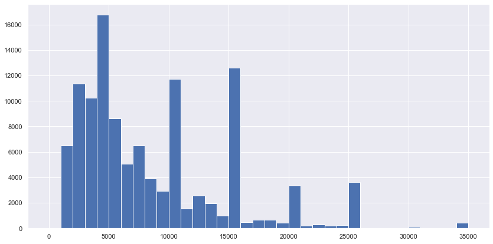

```python
base_color = sb.color_palette()[0]
plt.figure(figsize=[14,7])
# Use the `color` argument
bins = np.arange(0, df_status['LoanOriginalAmount'].max()+1000, 1000)

plt.hist(data = df_status, x = 'LoanOriginalAmount', bins = bins);
```

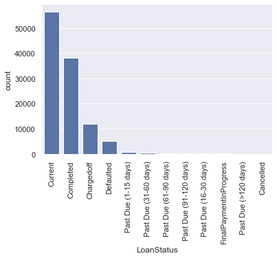

```python
# start with a standard-scaled plot
base_color = sb.color_palette()[0]

# Use the `color` argument
sb.countplot(data=df_status, x='LoanStatus', color=base_color, order =df_status['LoanStatus'].value_counts(normalize=True).index );
plt.xticks(rotation =90);
```

```
             Fig(1.1) histogram for the Loan status
```

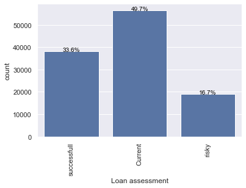

```python
n_assess = df_status['loan_asses'].value_counts().sum()
type_counts = df_status['loan_asses'].value_counts()

# Return the highest frequency in the `type` column
max_type_count = type_counts[0]

# Return the maximum proportion, or in other words,
# compute the length of the longest bar in terms of the proportion
max_prop = max_type_count / n_assess

base_color = sb.color_palette()[0]

sb.countplot(data=df_status, x='loan_asses', color=base_color);
plt.xlabel('Loan assessment')
type_counts = df_status['loan_asses'].value_counts()

# get the current tick locations and labels
locs, labels = plt.xticks(rotation=90)

# loop through each pair of locations and labels
for loc, label in zip(locs, labels):

    # get the text property for the label to get the correct count
    count = type_counts[label.get_text()]
    pct_string = '{:0.1f}%'.format(100*count/n_assess)

    # print the annotation just below the top of the bar
    plt.text(loc, count+2, pct_string, ha = 'center', color = 'black')
```

```
             Fig(1.2) histogram for the simplified Loan status
```

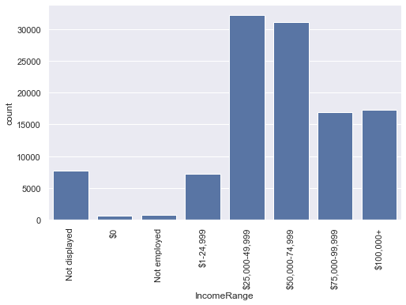

```python
base_color = sb.color_palette()[0]
plt.figure(figsize=[8, 5])
sb.countplot(data = df_status, x = 'IncomeRange', color=base_color,
             order =['Not displayed', '$0','Not employed', '$1-24,999','$25,000-49,999',  '$50,000-74,999', '$75,000-99,999', '$100,000+'] )
plt.xlabel('IncomeRange')
plt.xticks(rotation = 90)


plt.show()
```

```
             Fig(1.3) histogram for income ranges of borrowers
```

Now lets take a look at the Employment & occupation of our dataframe

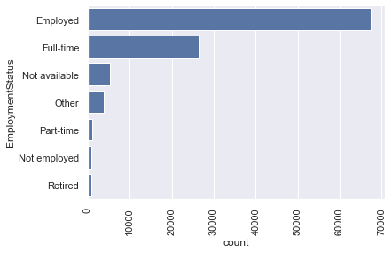

```python
# start with a standard-scaled plot
base_color = sb.color_palette()[0]

# Use the `color` argument
sb.countplot(data=df_status, y='EmploymentStatus', color=base_color, order = df_status.EmploymentStatus.value_counts().index);
plt.xticks(rotation =90);
```

```
             Fig(1.4) histogram for status of employement of borrowers
```

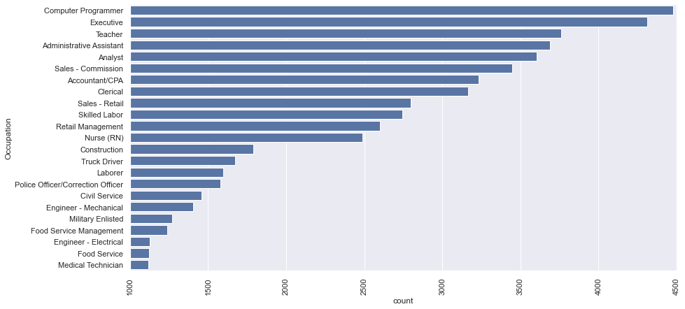

```python
# start with a standard-scaled plot
base_color = sb.color_palette()[0]
plt.figure(figsize = [14,7])
# exclude (professional and others from the histogram to see clearer)
sb.countplot(data=df_status, y='Occupation', color=base_color, order = df_status['Occupation'].value_counts(normalize=True).index[2:-42]);
plt.xlim([1000,4500])
plt.xticks(rotation =90);
```

```
                             Fig(1.5) histogram for Occupation of burrowers
```

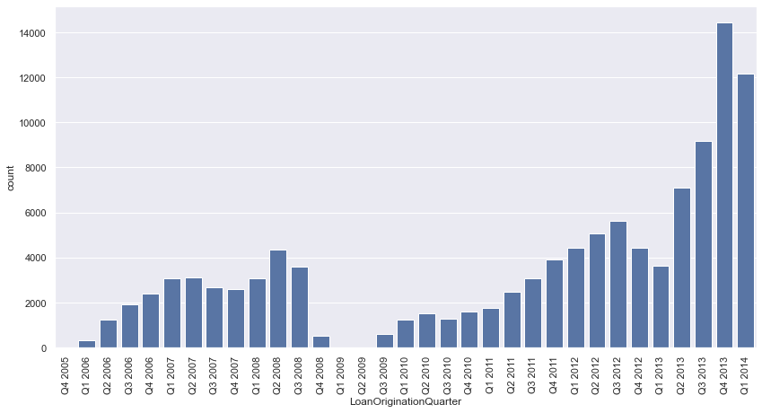

```python
#exporing the rate of issuing loans by the bank from 2009-2014

Quarter_order = ['Q4 2005', 'Q1 2006', 'Q2 2006',
             'Q3 2006', 'Q4 2006', 'Q1 2007', 'Q2 2007', 'Q3 2007',
             'Q4 2007', 'Q1 2008', 'Q2 2008', 'Q3 2008', 'Q4 2008',
             'Q1 2009', 'Q2 2009', 'Q3 2009', 'Q1 2010', 'Q2 2010',
             'Q3 2010', 'Q4 2010', 'Q1 2011', 'Q2 2011', 'Q3 2011',
            'Q4 2011', 'Q1 2012', 'Q2 2012', 'Q3 2012', 'Q4 2012', 'Q1 2013',
              'Q2 2013', 'Q3 2013', 'Q4 2013', 'Q1 2014']
base_color = sb.color_palette()[0]
plt.figure(figsize = [14,7])

sb.countplot(x="LoanOriginationQuarter",
             data=df_status, order = Quarter_order, color = base_color)
plt.setp(p.get_xticklabels(), rotation=90);  # Rotate labels
plt.xticks(rotation = 90);
```

```
                         Fig(1.6) histogram for number of issued loans
```

### Discuss the distribution(s) of your variable(s) of interest. Were there any unusual points? Did you need to perform any transformations?

1 - From fig(1.2) can see in the simplified loan status that about 16% of the loans were not a succesful investment for the bank.

2 - In fig(1.3) we notice that the most issued loans are done for incomes ranging from 25k - 75k USD.

3 - In fig(1.4) & fig(1.5) We can see that most of the loans are given to employed individuals mainly to computer programmers and Executives.

### Of the features you investigated, were there any unusual distributions? Did you perform any operations on the data to tidy, adjust, or change the form of the data? If so, why did you do this?

When investigating the dataframe, I found that the features of predictors in the bank changed drastically before 2009, and after 2009, so we will have to investigate the dataframe after and before to have better results, and as well to see if there is a signficant difference on the loans outcomes with the new system.

## Bivariate Exploration

To start off with, I want to look at the pairwise correlations present between features in the data.

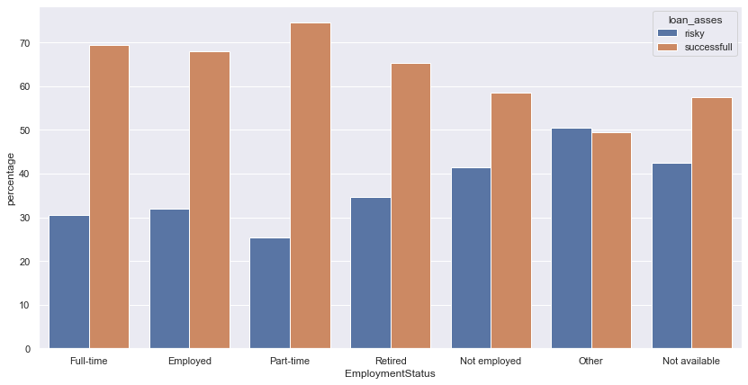

```python
#we remove the current count as it is not an indicator and will cause noise to our illustratation.
df_status2 = df_status[df_status['loan_asses'].isin(['risky','successfull'])]

#Now we produce a bivariate histogram for Employment Status with hue of Loan_asses.

plt.figure(figsize = [14,7])
Employement_counts = (df_status2.groupby(['EmploymentStatus'])['loan_asses']
                      .value_counts(normalize=True, sort=False).rename('percentage')
                      .mul(100).reset_index().sort_values('EmploymentStatus'))
sb.barplot(x="EmploymentStatus", y="percentage", hue="loan_asses", data=Employement_counts, order =Employement_counts.EmploymentStatus.value_counts().index )
plt.setp(p.get_xticklabels(), rotation=90);  # Rotate labels
```

```
 Fig(2.1) Percentages of successful and risky loan outcomes for each employment status
```

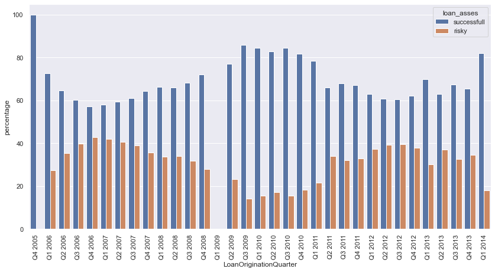

```python
#Now we produce a bivariate histogram for Employment Status with hue of Loan_asses.

plt.figure(figsize = [14,7])
Employement_counts = (df_status2.groupby(['LoanOriginationQuarter'])['loan_asses']
                      .value_counts( normalize= True,sort=False).rename('percentage')
                      .mul(100).reset_index().sort_values('LoanOriginationQuarter'))
sb.barplot(x="LoanOriginationQuarter", y="percentage", hue="loan_asses", data=Employement_counts, order =Quarter_order )
plt.setp(p.get_xticklabels(), rotation=90);  # Rotate labels
plt.xticks(rotation = 90);
```

```
      Fig(2.2) Percentages of successful and risky loan outcomes with time
```

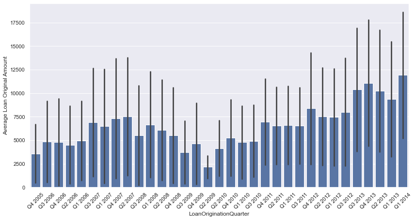

```python
#exploring the average amount of loans by the bank from 2009-2014

plt.figure(figsize=[14,7])

base_color = sb.color_palette()[0]
sb.barplot(data=df_status, x='LoanOriginationQuarter', y='LoanOriginalAmount', color=base_color, ci='sd')
plt.xticks(rotation=45);
plt.ylabel('Average Loan Original Amount');
```

```
                        Fig(2.3) average loan amount trending with time
                                (with variance represented)
```

```python
#we divide the dataframe into two dataframes, one with percentage of Occupations that are succesfull,
#while other is percentage of Risky occupations.

df_success_sub = df_status2.groupby(['Occupation'])['loan_asses'].value_counts( normalize= True,sort=False).rename('percentage').mul(100).reset_index().sort_values('Occupation')
df_success_sub = df_success_sub.query('loan_asses == "successfull"')
df_success_sub = df_success_sub.sort_values(by=['percentage'], ascending=False)

df_risky_sub = df_status2.groupby(['Occupation'])['loan_asses'].value_counts( normalize= True,sort=False).rename('percentage').mul(100).reset_index().sort_values('Occupation')
df_risky_sub = df_risky_sub.query('loan_asses == "risky"')
df_risky_sub = df_risky_sub.sort_values(by=['percentage'], ascending=False)
```

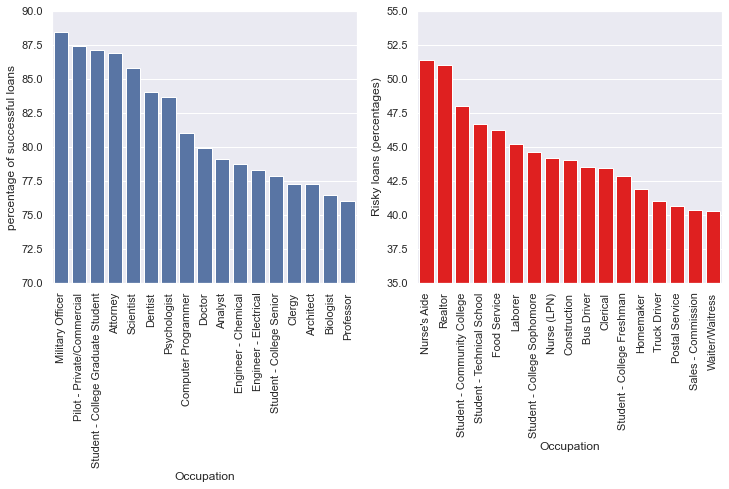

```python
plt.figure(figsize = [12, 5])

plt.subplot(1,2,1)

base_color = sb.color_palette()[0]
sb.barplot(data=df_success_sub, x='Occupation', y='percentage', color=base_color, order = df_success_sub['Occupation'][0:-50])
plt.xticks(rotation=90);
plt.ylabel('percentage of successful loans');
plt.ylim((70,90))
plt.subplot(1,2,2)

base_color = sb.color_palette()[0]
sb.barplot(data=df_risky_sub, x='Occupation', y='percentage', color='red', order = df_risky_sub['Occupation'][0:-50])
plt.xticks(rotation=90);
plt.ylim((35,55))
plt.ylabel('Risky loans (percentages)');
```

```
                  Fig(2.4) Most successful and riskiest occupation groups
```

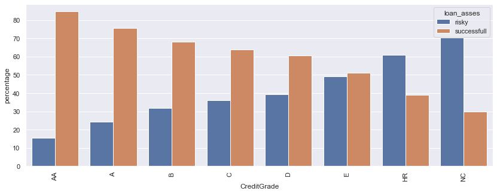

```python
Credit_counts = (org_be_09.groupby('CreditGrade')['loan_asses']
                     .value_counts(normalize=True)
                     .rename('percentage')
                     .mul(100)
                     .reset_index()
                     .sort_values('loan_asses'))
plt.figure(figsize=[14,5])
p = sb.barplot(x="CreditGrade", y="percentage", hue="loan_asses", data=Credit_counts, order = ['AA', 'A', 'B', 'C', 'D', 'E', 'HR', 'NC'])
_ = plt.setp(p.get_xticklabels(), rotation=90)  # Rotate labels
```

```
                 Fig(2.5) Percentage of success and risk related to Credit grades
```

```python
# to study the loans outcomes we should remove all the status: 'current' ,
# since its outcome is not yet concluded, and it will only cause noise.

org_be_09 = df_status[df_status['CreditGrade'].notna()].iloc[:]
org_af_09 = df_status[df_status['ProsperScore'].notna()].iloc[:]
print("number of rows before removing current loan status: ", org_af_09.shape[0])
org_af_09 = org_af_09.loc[org_af_09['loan_asses'].isin(['successfull','risky'])]
print("number of rows after removing current loan status: ",org_af_09.shape[0])
```

```
number of rows before removing current loan status:  84853
number of rows after removing current loan status:  28277
```

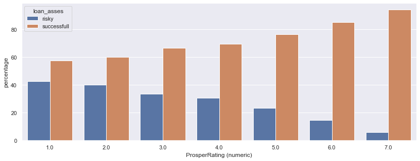

```python
Credit_counts = (org_af_09.groupby('ProsperRating (numeric)')['loan_asses']
                     .value_counts(sort=False, normalize=True)
                     .rename('percentage')
                     .mul(100)
                     .reset_index()
                     .sort_values('ProsperRating (numeric)'))
plt.figure(figsize=[14,5])
p = sb.barplot(x="ProsperRating (numeric)", y="percentage", hue="loan_asses", data=Credit_counts, order = org_af_09['ProsperRating (numeric)'].unique().sort())
_ = plt.setp(p.get_xticklabels(), rotation=0)
```

```
                 Fig(2.6) Percentage of success and risk related to prosper rating
```

### Talk about some of the relationships you observed in this part of the investigation. How did the feature(s) of interest vary with other features in the dataset?

`From plotting figure (2.1) to fig(2.6) we can observe the following:`

1- fig(2.1) Employment status is having a strong relationship with the probability of success of a loan for the bank, what was noted here is that part timers having a higher success rate than full timers.

2- fig(2.2) we notice the clear trend of succesful loans by bank over the years, notably after the new system applied in 2009, having the maximum rate of success in the 3rd quarter of 2009.

3- fig(2.3) we can see the the bank after changing its loan assesment policy that the started to issue more loans startng from 2009.

## Multivariate Exploration

The main thing I want to explore in this part of the analysis is the features affecting our questions put into play into the report.

```python
#we need to format the time to a unified time format
import datetime as dt
df_status[['ListingCreationDate', 'ClosedDate',
           'DateCreditPulled', 'FirstRecordedCreditLine',
           'LoanOriginationDate']] = df_status[['ListingCreationDate', 'ClosedDate', 'DateCreditPulled', 'FirstRecordedCreditLine', 'LoanOriginationDate']].apply(pd.to_datetime)
```

```python
time =['ListingCreationDate', 'ClosedDate', 'DateCreditPulled', 'FirstRecordedCreditLine', 'LoanOriginationDate']

for i in time :
    df_status[i] = df_status[i].dt.strftime('%m/%d/%Y')

#After we have the same code structure for the time, now we convert it back to date format.
df_status[time] = df_status[['ListingCreationDate', 'ClosedDate', 'DateCreditPulled', 'FirstRecordedCreditLine', 'LoanOriginationDate']].apply(pd.to_datetime)
```

```python
# we will encode all objects into integers so we can get correlation with each other
from sklearn.preprocessing import LabelEncoder
from sklearn.compose import ColumnTransformer
le = LabelEncoder()
```

```python
# This function should remove highly correlated descriptors(columns) from any dataset with specified correlation threshold
def correlation(dataset, threshold):
    """ Removes all columns with internal correlation with each other if they are than the specified 'threshold' """
    col_corr = set() # Set of all the names of deleted columns
    corr_matrix = dataset.corr()
    for i in range(len(corr_matrix.columns)):
        for j in range(i):
            if (corr_matrix.iloc[i, j] >= threshold or corr_matrix.iloc[i, j] <= -threshold) and (corr_matrix.columns[j] not in col_corr):
                colname = corr_matrix.columns[i] # getting the name of column
                col_corr.add(colname)
                if colname in dataset.columns:
                    del dataset[colname] # deleting the column from the dataset

    print(dataset.columns)
```

```python
# we list the object columns in our dataframe so we can convert in to numbers
print(df_status.select_dtypes(include = 'object').columns)
print(df_status.shape)
```

```
Index(['ListingKey', 'BorrowerState', 'Occupation', 'GroupKey', 'LoanKey',
       'MemberKey', 'loan_stat', 'loan_asses'],
      dtype='object')
(113937, 83)
```

```python
from sklearn.preprocessing import LabelEncoder
from sklearn.compose import ColumnTransformer
le = LabelEncoder()
```

```python
categ = ['ListingKey', 'BorrowerState', 'Occupation', 'GroupKey', 'LoanKey',
       'MemberKey', 'loan_asses']
for cat in categ:

    org_be_09[cat] = org_be_09[cat].astype(str)
    org_be_09[cat] = le.fit_transform(org_be_09[cat])
```

```
Index(['loan_asses', 'LoanCurrentDaysDelinquent', 'LP_GrossPrincipalLoss',
       'LP_CustomerPrincipalPayments', 'BorrowerRate', 'CreditScoreRangeLower',
       'TotalInquiries'],
      dtype='object')
```

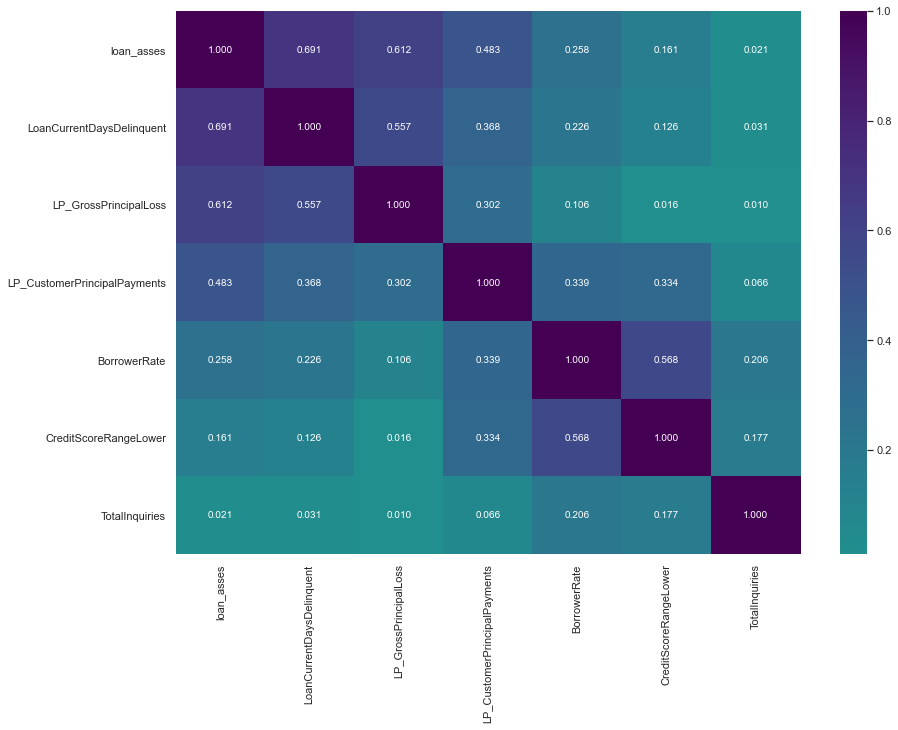

```python
# main factors affecting Loan assesment before 2009
# We make a list of the top 12 highest (absolute) factors affecting Loan assesment

loan_corr_abs1 = list(abs(org_be_09.corr()['loan_asses'][:]).nlargest(12).index)

loan_corr1 = org_af_09[loan_corr_abs1]

correlation(loan_corr1, 0.8)
plt.figure(figsize = [14, 10])
sb.heatmap(abs(loan_corr1.corr()), annot = True, fmt = '.3f',
           cmap = 'viridis_r', center = 0)
plt.show();
```

```
                 Fig(3.0) Correlation between loan outcomes and correlated factors
                 affecting it.
```

### Question number 1 : What factors affect a loan’s outcome status?

### We will investigate in this report only after 2009 .

we will check the factors affecting the loan assesment :

```python
categ = ['ListingKey', 'BorrowerState', 'Occupation', 'GroupKey', 'LoanKey',
       'MemberKey', 'loan_asses']
for cat in categ:
    org_af_09[cat] = org_af_09[cat].astype(str)
    org_af_09[cat] = le.fit_transform(org_af_09[cat])
```

```
Index(['loan_asses', 'LoanCurrentDaysDelinquent', 'LP_GrossPrincipalLoss',
       'LP_CustomerPrincipalPayments', 'EstimatedEffectiveYield',
       'LenderYield', 'ProsperScore'],
      dtype='object')
```

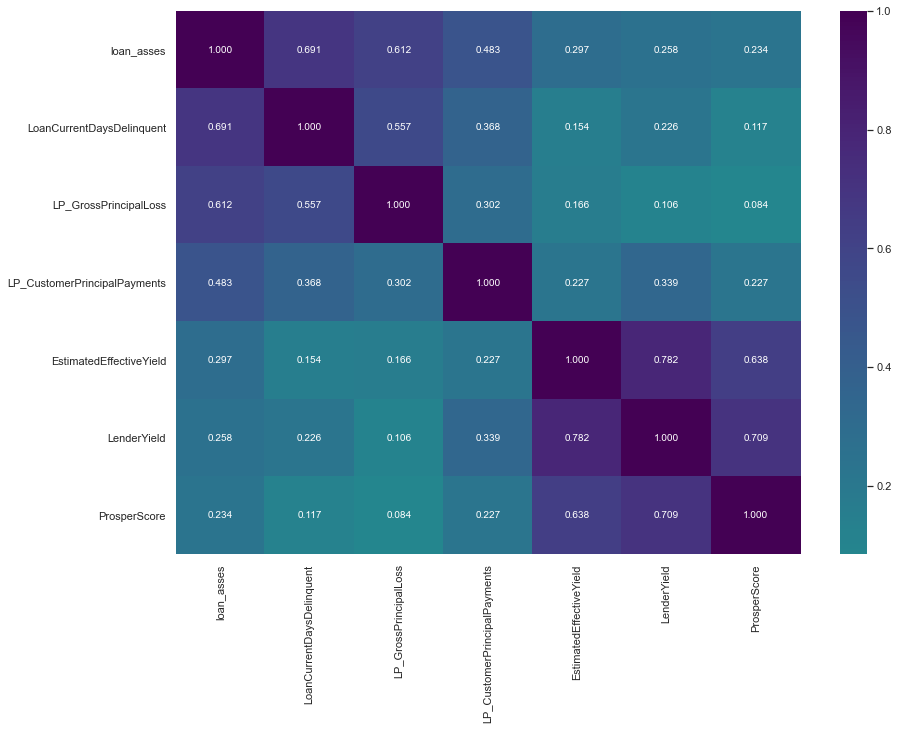

```python
# main factors affecting Loan assesment after 2009
# We make a list of the top 12 highest (absolute) factors affecting Loan assesment

loan_corr_abs = list(abs(org_af_09.corr()['loan_asses'][:]).nlargest(12).index)

loan_corr = org_af_09[loan_corr_abs]

correlation(loan_corr, 0.8)
plt.figure(figsize = [14, 10])
sb.heatmap(abs(loan_corr.corr()), annot = True, fmt = '.3f',
           cmap = 'viridis_r', center = 0)
plt.show();
```

```
                 Fig(3.1) Correlation between loan outcomes and correlated factors
                 affecting it.
```

```
Index(['ProsperRating (numeric)', 'EstimatedEffectiveYield',
       'CreditScoreRangeLower', 'EstimatedReturn', 'Investors',
       'AvailableBankcardCredit'],
      dtype='object')
```

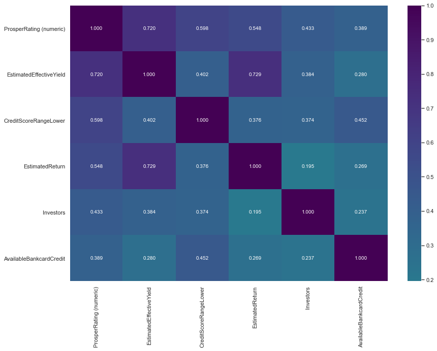

```python
# main factors affecting prosper rating after 2009
# We make a list of the top 12 highest (absolute) factors affecting Prosper Rating

prosp_corr_abs = list(abs(org_af_09.corr()['ProsperRating (numeric)'][:]).nlargest(12).index)
prosp_corr_abs.remove('ProsperScore')
prosp_corr = org_af_09[prosp_corr_abs]

correlation(prosp_corr, 0.8)
plt.figure(figsize = [14, 10])
sb.heatmap(abs(prosp_corr.corr()), annot = True, fmt = '.3f',
           cmap = 'viridis_r', center = 0)
plt.show();
```

```
                 Fig(3.2) Correlation between prosper rating and correlated factors
                 affecting it.
```

```python
#Getting dataset with categorical values again
df_af_09 = df_status[df_status['ProsperScore'].notna()].iloc[:]
df_af_09 = df_af_09.drop(['CreditGrade', 'GroupKey','LoanFirstDefaultedCycleNumber' ], axis=1)
df_af_09.shape
```

```
(84853, 80)
```

```python
df_af_09['loan_asses'].value_counts(normalize=True)
```

```
Current        0.666753
successfull    0.234158
risky          0.099089
Name: loan_asses, dtype: float64
```

### Short brief for the factors affecting Loan assesments:

```python
df_af_09.query('loan_asses == "successfull"')['ProsperRating (numeric)'].value_counts(normalize=True).sort_index(ascending=False)
```

```
7.0    0.086215
6.0    0.162917
5.0    0.142131
4.0    0.151744
3.0    0.212391
2.0    0.127737
1.0    0.116865
Name: ProsperRating (numeric), dtype: float64
```

```python
df_af_09.groupby('Term')['loan_asses'].value_counts(normalize=True)
```

```
Term  loan_asses
12    successfull    0.904526
      risky          0.057037
      Current        0.038438
36    Current        0.619934
      successfull    0.271710
      risky          0.108357
60    Current        0.820004
      successfull    0.100306
      risky          0.079690
Name: loan_asses, dtype: float64
```

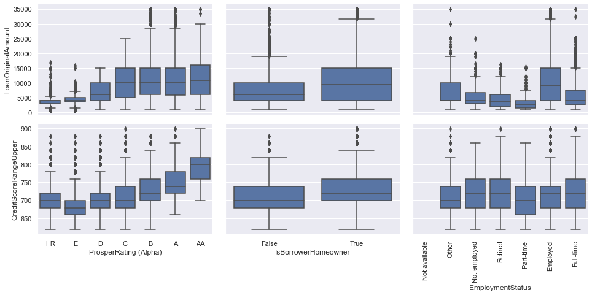

```python
# plot matrix of numeric features against categorical features.
# can use a larger sample since there are fewer plots and they're simpler in nature.
categoric_vars = ['ProsperRating (Alpha)', 'IsBorrowerHomeowner','EmploymentStatus' ]
def boxgrid(x, y, **kwargs):
    """ Quick hack for creating box plots with seaborn's PairGrid. """
    default_color = sb.color_palette()[0]
    sb.boxplot(x=x, y=y, color = default_color)

plt.figure(figsize = [14, 14])

g = sb.PairGrid(data = org_af_09, y_vars = ['LoanOriginalAmount', 'CreditScoreRangeUpper'], x_vars = categoric_vars,
                height = 3, aspect = 1.5)
plt.xticks(rotation = 90)
g.map(boxgrid)
plt.show();
```

```
                Fig(3.3) Box matrix of numeric features against categorical features.
```

##### Not anticipated trends:

```python
org_af_09['AvailableBankcardCredit'].describe()
```

```
count     28277.000000
mean      10991.726739
std       20205.609884
min           0.000000
25%         824.000000
50%        4045.000000
75%       13000.000000
max      498374.000000
Name: AvailableBankcardCredit, dtype: float64
```

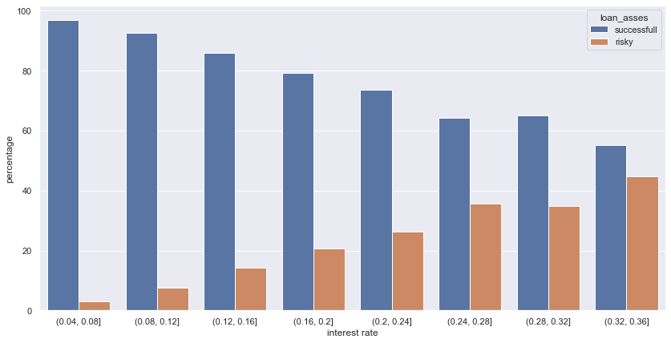

```python
#Now we produce a bivariate histogram for Employment Status with hue of Loan_asses.

plt.figure(figsize = [14,7])
interestRate_success = (org_af_09[org_af_09['loan_asses'].isin(['risky','successfull'])].groupby(['BorrowerAPR_bins'])['loan_asses']
                      .value_counts(normalize=True, sort=True).rename('percentage')
                      .mul(100).reset_index().sort_values('BorrowerAPR_bins'))
sb.barplot(x="BorrowerAPR_bins", y="percentage", hue="loan_asses", data=interestRate_success, order =org_af_09.BorrowerAPR_bins.value_counts(sort=False).index )
plt.xlabel('interest rate')
plt.setp(p.get_xticklabels(), rotation=90);  # Rotate labels
```

```
                 Fig(3.4) Correlation between interest rate and percentage of success/risk
                                         in loan assesment.
```

```python
df_af_09['StatedMonthlyIncome'].describe()
```

```
count    8.485300e+04
mean     5.931175e+03
std      8.239944e+03
min      0.000000e+00
25%      3.434000e+03
50%      5.000000e+03
75%      7.083333e+03
max      1.750003e+06
Name: StatedMonthlyIncome, dtype: float64
```

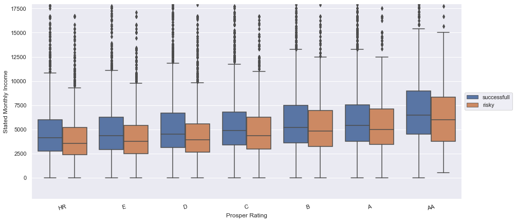

```python
plt.figure(figsize = [15,7])
sb.boxplot(data = df_af_09[df_af_09['loan_asses'].isin(['risky','successfull'])], x = 'ProsperRating (Alpha)', y = 'StatedMonthlyIncome', hue = 'loan_asses', hue_order = ['successfull', 'risky'])
plt.ylim([-2200,18000])
plt.legend(loc = 6, bbox_to_anchor = (1.0, 0.5)) # legend to right of figure
plt.ylabel('Stated Monthly Income')
plt.xlabel('Prosper Rating')
plt.xticks(rotation = 15);
```

```
        Fig(3.5) Multivariate box diagram between prosper rating for successful and risky
                              loan assesments with Monthly income.
```

### Question number 2 : What affects the borrower’s APR or interest rate?

```
Index(['BorrowerAPR', 'EstimatedReturn', 'InquiriesLast6Months',
       'BankcardUtilization', 'LoanMonthsSinceOrigination',
       'LP_InterestandFees', 'ProsperScore', 'CreditScoreRangeLower',
       'LoanOriginalAmount', 'AvailableBankcardCredit',
       'TradesNeverDelinquent (percentage)'],
      dtype='object')
```

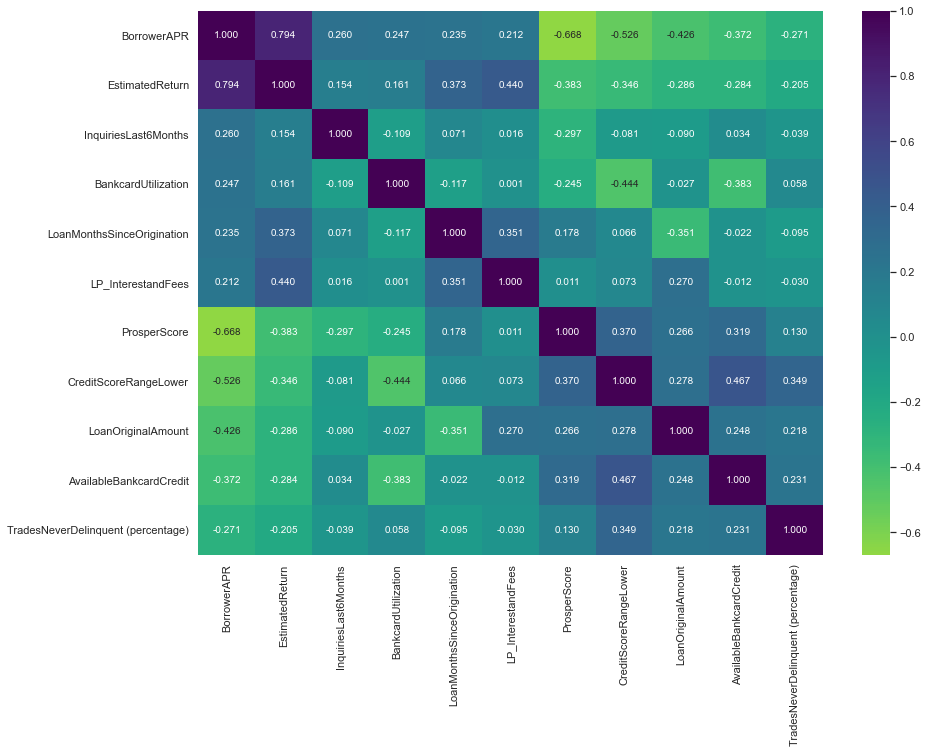

```python
APR_corr = list(org_af_09.corr()['BorrowerAPR'][:].nlargest(10).index)+ list(org_af_09.corr()['BorrowerAPR'][:].nsmallest(10).index)

APR_correlate = org_af_09[APR_corr]

correlation(APR_correlate, 0.8)
plt.figure(figsize = [14, 10])
sb.heatmap(APR_correlate.corr(), annot = True, fmt = '.3f',
           cmap = 'viridis_r', center = 0)

plt.show();
```

```
                Fig(3.7) Correlation  diagram between borrow APR and main factors affecting it.
```

#### **Main factors affecting interest rate here are :**

- **ProsperScore** : The more score can decrease the interest rate on the loan, as it is an indication of a low risk client.
- **credit score range** : The more score can decrease the interest rate on the loan, as it is an indication of a low risk client.
- **Available Bank card credit** : The total available credit via bank card can have an effect on the interest rate given by bank.

#### **Further investigation into these features :**

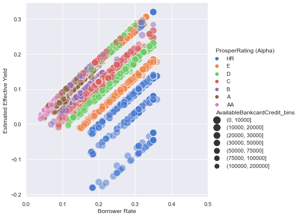

```python
# scatter plot of BorrowerRate vs. Estimated Effective Yield

sb.relplot(x="BorrowerRate", y="EstimatedEffectiveYield", hue="ProsperRating (Alpha)", size="AvailableBankcardCredit_bins",
            sizes=(80, 200), alpha=.5, palette="muted",
            height=6, data=org_af_09)
plt.xlim([0, .5])
plt.xlabel('Borrower Rate')

plt.ylabel('Estimated Effective Yield')
plt.show()
```

```
                Fig(3.8) scatter diagram featuring interest rate with Estimated Effective yield
              for two types of differernt categories (Available bankcard amount & Prosper Rating).
```

This plot suggests from the direct relationship between the increasing rate of interest and estimated yield.

#### **Borrower APR vs Prosper score :**

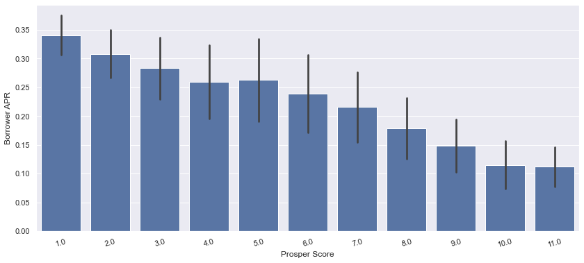

```python
base_color = sb.color_palette()[0]
plt.figure(figsize=[14,6])
sb.barplot(data=LoanOr_Amount_correlate, x='ProsperScore', y='BorrowerAPR', color=base_color, ci='sd')
plt.xticks(rotation=15);
plt.ylabel('Borrower APR')
plt.xlabel('Prosper Score');
```

```
                Fig(3.9) barchat diagram featuring interest rate with prosper score
```

### Question number 3 : to see if there are differences between loans depending on how large the original loan amount was?

```
Index(['LoanOriginalAmount', 'ProsperRating (numeric)',
       'ProsperPrincipalBorrowed', 'LoanNumber', 'Term', 'Investors',
       'CreditScoreRangeLower', 'LP_ServiceFees', 'EstimatedReturn',
       'loan_asses', 'ListingCategory (numeric)'],
      dtype='object')
```

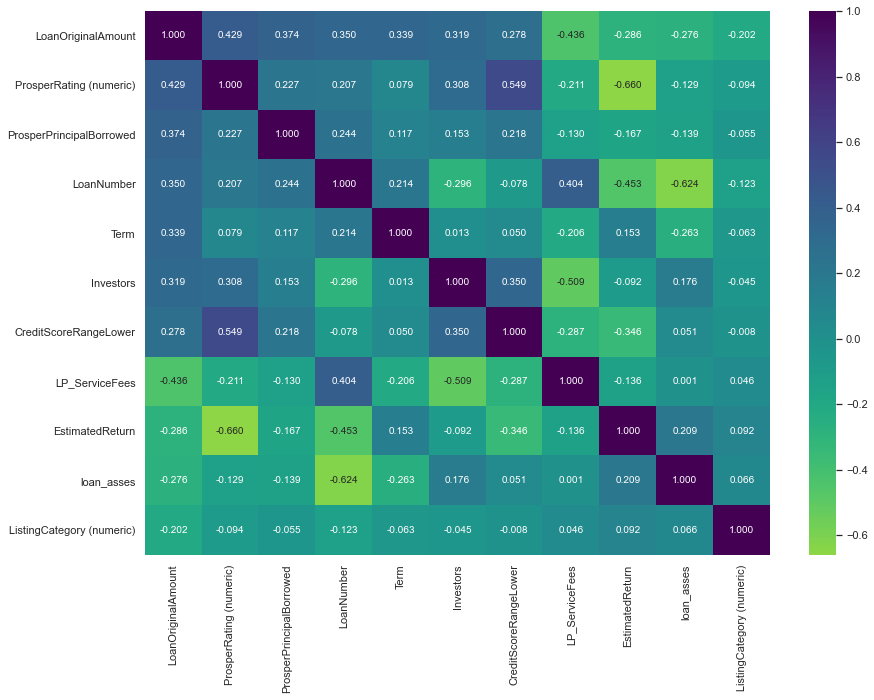

```python
Loan_Amount_corr = list(org_af_09.corr()['LoanOriginalAmount'][:].nlargest(10).index)+ list(org_af_09.corr()['LoanOriginalAmount'][:].nsmallest(10).index)

Loan_Amount_correlate = org_af_09[['LoanOriginalAmount', 'ProsperRating (numeric)',
       'ProsperPrincipalBorrowed', 'LoanNumber', 'Term', 'Investors',
       'CreditScoreRangeLower', 'LP_ServiceFees', 'EstimatedReturn',
       'loan_asses', 'ListingCategory (numeric)']]

correlation(Loan_Amount_correlate, 0.8)
plt.figure(figsize = [14, 10])
sb.heatmap(Loan_Amount_correlate.corr(), annot = True, fmt = '.3f',
           cmap = 'viridis_r', center = 0)
plt.show();
```

```
                Fig(3.10) Correlation  diagram between  Loan amount and main factors affecting it.
```

#### **Further investigation Listing category vs Loan amount :**

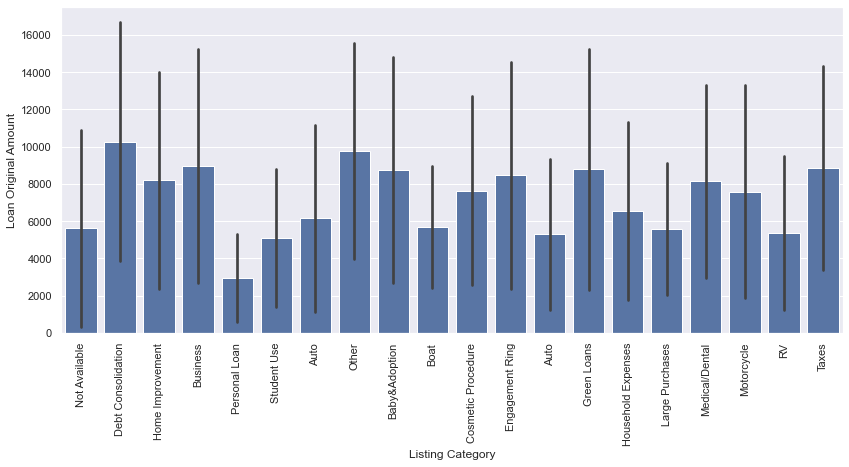

```python
base_color = sb.color_palette()[0]
plt.figure(figsize=[14,6])

sb.barplot(data=Loan_Amount_correlate, x='ListingCategory (numeric)', y='LoanOriginalAmount', color=base_color, ci='sd')
plt.xticks(rotation=90);
plt.xlabel('Listing Category')
plt.ylabel('Loan Original Amount');
plt.xticks(np.arange(20), ['Not Available', 'Debt Consolidation', 'Home Improvement', 'Business', 'Personal Loan', 'Student Use', 'Auto', 'Other', 'Baby&Adoption', 'Boat', 'Cosmetic Procedure', 'Engagement Ring', 'Auto', 'Green Loans', 'Household Expenses', 'Large Purchases', 'Medical/Dental', 'Motorcycle', 'RV','Taxes']) ;
```

```python
corr_smalles3 = list(org_af_09.corr()['BorrowerAPR'][:].nsmallest(10).index)
corr_larges3 = list(org_af_09.corr()['BorrowerAPR'][:].nlargest(10).index)

org_af_09_correlate2 = org_af_09[corr_larges3+corr_smalles3 ]

correlation(org_af_09_correlate2, 0.8)
plt.figure(figsize = [14, 10])
sb.heatmap(org_af_09_correlate2.corr(), annot = True, fmt = '.3f',
           cmap = 'viridis_r', center = 0)
plt.show();
```

[output not shown]

We notice here that the bank system regarding loans has changed after year 2009. So we divide our dataset into two datasets to see which relevant factors affects the success of a loan:

> At the end of your report, make sure that you export the notebook as an html file from the `File > Download as... > HTML` menu. Make sure you keep track of where the exported file goes, so you can put it in the same folder as this notebook for project submission. Also, make sure you remove all of the quote-formatted guide notes like this one before you finish your report!